# Social Influence Effect on Aesthetic Judgments: Full Manuscript

Author

Omar Lizardo & Sara Skiles

Published

June 1, 2026

# 1. Introduction

## 1.1 Abstract and Overview

In this paper we address the question, foundational to sociological studies of taste, of the extent to which the aesthetic judgment of others influence the transient evaluation of cultural works, and the extent to which this influence depends on the social distance between self and other. Drawing on classic and recent cultural theory, we hypothesize that high (low) status respondents (as indexed by educational attainment) will be more likely to change their judgment of a cultural object in a negative direction when exposed to information about the negative aggregate judgment of other persons of high (low) status in comparison to when those judgments come from others of low (high) status. We use a quasi-experimental design to manipulate both exposure to the evaluations of others as well as the status characteristics of those others.

## 1.2 Theoretical Background

How does access to the evaluations of others influence our own aesthetic evaluations of cultural objects? Traditional models in the sociology of culture and consumption use a balance-like logic, suggesting that access to positive evaluations on the part of others will lead to an increase in subjective evaluations of worth when those others are positively regarded but not when they are negatively regarded. In the same way, access to other people’s negative evaluations will lead to a decrease in subjective evaluations of worth when those others are positively regarded.

The basic idea behind generalized influence mechanisms is simple: in any context in which there is some level of uncertainty as to how to evaluate a cultural object, access to information regarding the way in which the cultural object has been evaluated by others helps resolve that uncertainty. However, influence is not monolithic. Exposure to the preferences of a high-status group might induce *conformity* (alignment), whereas exposure to a low-status or out-group might induce *reactance* (distancing). We specifically explore how the objective and subjective class status of the respondent interacts with the class status of the fictional group to produce theoretically distinct behaviors: staying, conforming, or reacting.

## 1.3 Hypotheses

**Baseline Condition (Mere Exposure Effect):** Overall we expect that mere exposure to the same cultural object over repeated trials results in an average improvement in evaluation, even in the absence of information on how other persons evaluate the object. Access to information regarding other people’s evaluations serves to block or facilitate this mere exposure effect.

**Evaluation Only Condition:** * **Positive Evaluations:** Positive evaluations (liking) from generalized others should have an overall positive influence on the respondent’s second evaluation, facilitating the baseline drift. * **Negative Evaluations:** Negative evaluations (disliking) from generalized others should have an overall negative influence on the respondent’s second evaluation, blocking the mere exposure effect.

**Status Plus Evaluation Conditions (Cross-Status Reactance and Symbolic Power):** * **Hypothesis 1 (Same-status association):** High (low) status respondents will be more likely to change their judgments in a negative direction when exposed to the aggregate negative judgment of others of high (low) status. * **Hypothesis 2 (Symbolic power):** Low status respondents will be more likely to change their judgments in a negative direction when exposed to the aggregate negative judgment of others of high status. * **Hypothesis 3 (Cross-status reactance):** High (low) status respondents will be more likely to change their judgments in a positive direction (distancing) when exposed to the negative aesthetic judgment of others of low (high) status.

# 2. Data and Methods

## 2.1 Experimental Design and Data

We utilize data from the SSI-2012 survey (`ssi2012_cleaned.dta`). The core of the study is a within-subject experimental design where respondents rate an artwork on a 7-point scale (“taste1”), are exposed to a treatment condition, and then rate the artwork again (“taste2”).

The treatment conditions vary along three dimensions regarding a fictional alter group: 1. **Taste Evaluation:** Whether the alter group *liked* or *disliked* the artwork. 2. **Status of the Alter:** High-status (College educated/Middle class) versus Low-status (Working class/No college). 3. **Control/Taste Only:** Conditions where only the alter’s taste is known, but no class information is provided, as well as a pure baseline control.

## 2.2 Variables

- **Dependent Variable:** The primary outcome is the shift in aesthetic evaluation. We analyze this as a continuous change score, an ordinal structure using Cumulative Link Mixed Models (CLMM), and a nominal behavioral outcome (Stay, Conform, React).
- **Independent Variables:** The experimental condition factors.
- **Moderators:** Respondent status consistency, captured by `objsubjclass_factor` (Working/Middle Class crossed with College/No College).

## 2.3 Analytic Strategy

Our data consists of repeated measures (before and after providing access to others’ evaluations) of the respondent’s aesthetic evaluation of a cultural object. Because repeated measures are correlated within subjects (but independent across subjects), we rely on random-effects models as a natural framework to simultaneously model within and between subjects variance. We use hierarchically nested versions of the mixed-effects model via maximum likelihood and use likelihood ratio tests to select the best fit.

To overcome the limitations of standard linear regression and fully test our hypotheses regarding alignment vs. distancing, we additionally employ three advanced modeling techniques: 1. **Cumulative Link Mixed Models (CLMM):** To respect the bounded, ordinal 1-7 scale of the dependent variable. 2. **Multinomial Logistic Regression:** To disaggregate shifts into Conformity and Reactance based on the direction of the alter’s feedback. 3. **Propensity Score Weighting (IPW):** To balance demographic covariates (age, gender, race, parent’s education) across observational status groups, ensuring the moderating effects of class are not confounded.

```r
library(lme4)
library(dplyr)
library(ggplot2)
library(modelsummary)
library(marginaleffects)
library(ordinal)
library(nnet)
library(WeightIt)
library(cobalt)

# Load data
source("R/dataproc.R")
data_list <- process_data()
df_long <- data_list$long
df_wide <- data_list$wide
```

# 3. Results

## 3.1 Linear Baseline and Trial Effects

First, we replicate the original nested linear mixed models. The model including the interaction between the experimental condition and the trial period provides the best fit, confirming that social influence varies significantly depending on the status of the fictional group.

```r
mod0 <- lmer(taste ~ 1 + (1 | id), data = df_long, REML = FALSE)
mod1 <- lmer(taste ~ cond_factor + (1 | id), data = df_long, REML = FALSE)
mod2 <- lmer(taste ~ factor(trial) + cond_factor + (1 | id), data = df_long, REML = FALSE)
mod3 <- lmer(taste ~ factor(trial) * cond_factor + (1 | id), data = df_long, REML = FALSE)
anova(mod0, mod1, mod2, mod3)
```

```
Data: df_long
Models:
mod0: taste ~ 1 + (1 | id)
mod1: taste ~ cond_factor + (1 | id)
mod2: taste ~ factor(trial) + cond_factor + (1 | id)
mod3: taste ~ factor(trial) * cond_factor + (1 | id)
     npar   AIC   BIC  logLik -2*log(L)   Chisq Df Pr(>Chisq)
mod0    3 12994 13013 -6494.0     12988
mod1   11 13002 13072 -6489.8     12980  8.5269  8  0.3837608
mod2   12 12981 13058 -6478.6     12957 22.4003  1  2.213e-06 ***
mod3   20 12965 13094 -6462.7     12925 31.8193  8  0.0001003 ***
---
Signif. codes:  0 '***' 0.001 '**' 0.01 '*' 0.05 '.' 0.1 ' ' 1
```

## 3.2 Trial Effects by Status Consistency

The effect of social influence is highly moderated by the respondent’s own class and educational background.

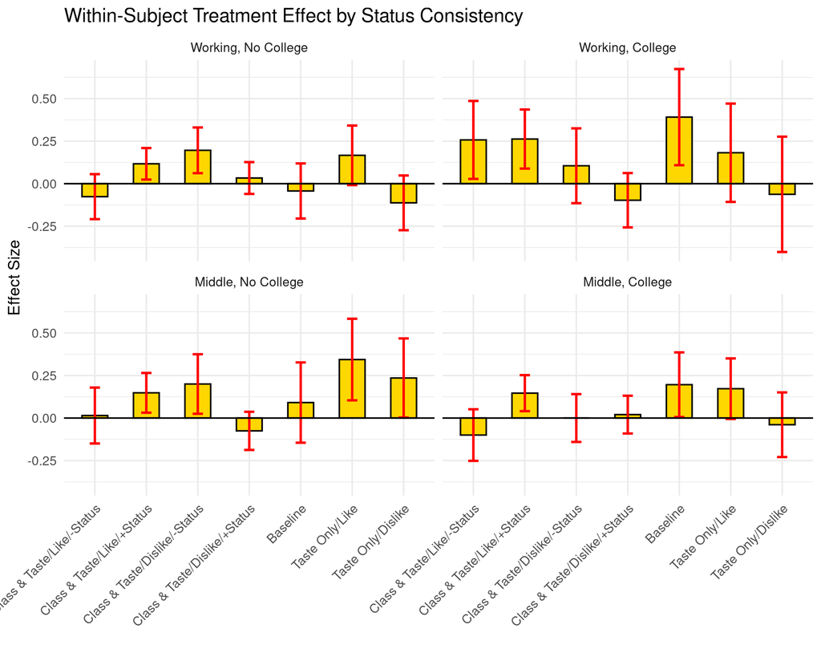

```r
mod_objsubj <- lmer(taste ~ factor(trial) * cond2_factor * objsubjclass_factor + (1 | id), data = df_long, REML = FALSE)
te_objsubj <- avg_comparisons(mod_objsubj, variables = "trial", by = c("cond2_factor", "objsubjclass_factor"))

ggplot(te_objsubj, aes(x = cond2_factor, y = estimate)) +
  geom_bar(stat = "identity", fill = "gold", color = "black", width = 0.5) +
  geom_errorbar(aes(ymin = conf.low, ymax = conf.high), width = 0.2, color = "red", linewidth = 1) +
  geom_hline(yintercept = 0, linetype = "solid", color = "black") +
  facet_wrap(~objsubjclass_factor, ncol = 2) +
  labs(title = "Within-Subject Treatment Effect by Status Consistency",
       x = "", y = "Effect Size") +
  theme_minimal(base_size = 14) +
  theme(axis.text.x = element_text(angle = 45, hjust = 1))
```

## 3.3 Cumulative Link Mixed Models (CLMM)

```r
df_long$taste_ord <- factor(df_long$taste, ordered = TRUE, levels = 1:7)
clmm_mod <- clmm(taste_ord ~ factor(trial) * cond2_factor + (1 | id), data = df_long)

# Display interaction coefficients
clmm_coefs <- coef(clmm_mod)[grep("trial.*cond", names(coef(clmm_mod)))]
round(clmm_coefs, 3)
```

[output not shown]

## 3.4 Disaggregating Behavior: Conformity vs. Reactance

Because a linear shift obscures whether a respondent is moving *toward* (Conformity) or *away from* (Reactance) the group, we map the behavioral shifts and fit a Multinomial Logistic Regression model.

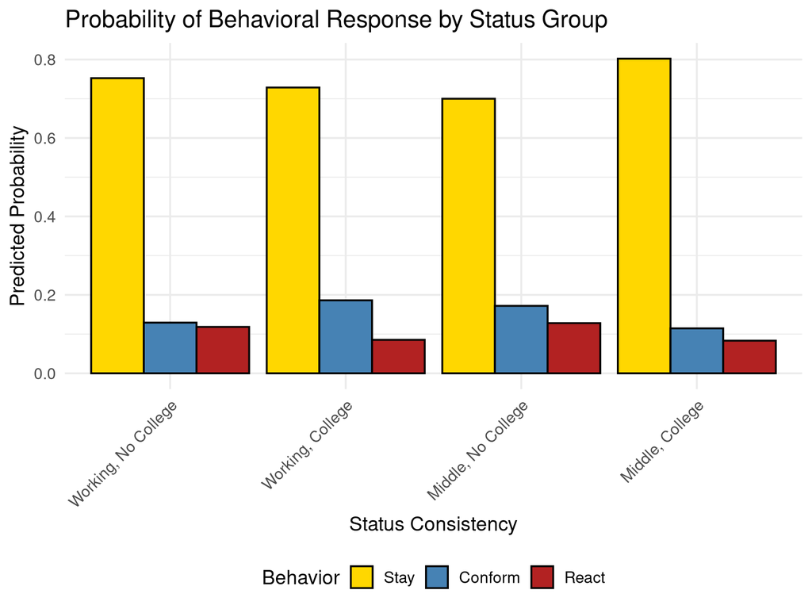

```r
df_multi <- df_wide %>%
  mutate(
    diff = taste2_rev - taste1_rev,
    behavior = case_when(
      cond2_factor == "Baseline" & diff == 0 ~ "Stay",
      cond2_factor == "Baseline" & diff > 0 ~ "Shift Up",
      cond2_factor == "Baseline" & diff < 0 ~ "Shift Down",
      cond2_factor %in% c("Class & Taste/Like/-Status", "Class & Taste/Like/+Status", "Taste Only/Like") & diff == 0 ~ "Stay",
      cond2_factor %in% c("Class & Taste/Like/-Status", "Class & Taste/Like/+Status", "Taste Only/Like") & diff > 0 ~ "Conform",
      cond2_factor %in% c("Class & Taste/Like/-Status", "Class & Taste/Like/+Status", "Taste Only/Like") & diff < 0 ~ "React",
      cond2_factor %in% c("Class & Taste/Dislike/-Status", "Class & Taste/Dislike/+Status", "Taste Only/Dislike") & diff == 0 ~ "Stay",
      cond2_factor %in% c("Class & Taste/Dislike/-Status", "Class & Taste/Dislike/+Status", "Taste Only/Dislike") & diff < 0 ~ "Conform",
      cond2_factor %in% c("Class & Taste/Dislike/-Status", "Class & Taste/Dislike/+Status", "Taste Only/Dislike") & diff > 0 ~ "React",
      TRUE ~ NA_character_
    )
  ) %>%
  filter(behavior %in% c("Stay", "Conform", "React")) %>%
  mutate(behavior = factor(behavior, levels = c("Stay", "Conform", "React")))

multi_mod <- multinom(behavior ~ objsubjclass_factor, data = df_multi, trace = FALSE)
multi_preds <- predictions(multi_mod, type = "probs", by = c("objsubjclass_factor", "group"))

ggplot(multi_preds, aes(x = objsubjclass_factor, y = estimate, fill = group)) +
  geom_bar(stat = "identity", position = "dodge", color = "black") +
  scale_fill_manual(values = c("Stay" = "gold", "Conform" = "steelblue", "React" = "firebrick")) +
  labs(title = "Probability of Behavioral Response by Status Group",
       x = "Status Consistency", y = "Predicted Probability", fill = "Behavior") +
  theme_minimal(base_size = 14) +
  theme(legend.position = "bottom", axis.text.x = element_text(angle = 45, hjust = 1))
```

## 3.5 Robustness: Covariate Balancing via IPW

To ensure these class-based findings are not driven by confounding demographics (like age or race disparities between education groups), we apply Propensity Score Weighting.

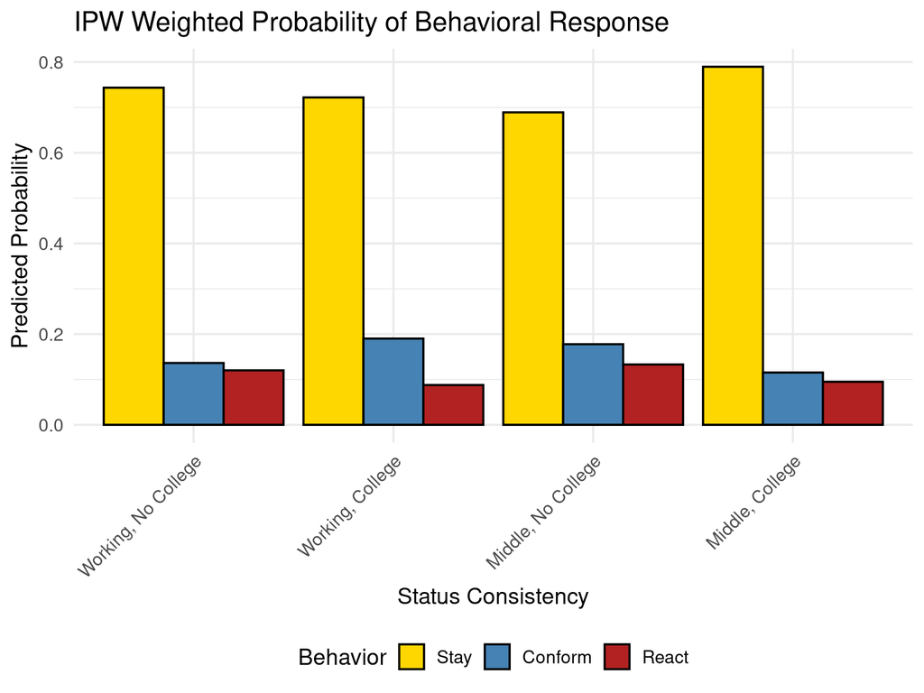

```r
df_wide_cc <- df_wide %>%
  filter(!is.na(objsubjclass_factor),
         !is.na(age), !is.na(female), !is.na(raceeth), !is.na(parented))

W <- weightit(objsubjclass_factor ~ age + female + factor(raceeth) + parented,
              data = df_wide_cc, method = "ps", estimand = "ATE")

df_wide_cc$ipw_weight <- W$weights

df_multi_wt <- df_wide_cc %>%
  mutate(
    diff = taste2_rev - taste1_rev,
    behavior = case_when(
      cond2_factor == "Baseline" & diff == 0 ~ "Stay",
      cond2_factor == "Baseline" & diff > 0 ~ "Shift Up",
      cond2_factor == "Baseline" & diff < 0 ~ "Shift Down",
      cond2_factor %in% c("Class & Taste/Like/-Status", "Class & Taste/Like/+Status", "Taste Only/Like") & diff == 0 ~ "Stay",
      cond2_factor %in% c("Class & Taste/Like/-Status", "Class & Taste/Like/+Status", "Taste Only/Like") & diff > 0 ~ "Conform",
      cond2_factor %in% c("Class & Taste/Like/-Status", "Class & Taste/Like/+Status", "Taste Only/Like") & diff < 0 ~ "React",
      cond2_factor %in% c("Class & Taste/Dislike/-Status", "Class & Taste/Dislike/+Status", "Taste Only/Dislike") & diff == 0 ~ "Stay",
      cond2_factor %in% c("Class & Taste/Dislike/-Status", "Class & Taste/Dislike/+Status", "Taste Only/Dislike") & diff < 0 ~ "Conform",
      cond2_factor %in% c("Class & Taste/Dislike/-Status", "Class & Taste/Dislike/+Status", "Taste Only/Dislike") & diff > 0 ~ "React",
      TRUE ~ NA_character_
    )
  ) %>%
  filter(behavior %in% c("Stay", "Conform", "React")) %>%
  mutate(behavior = factor(behavior, levels = c("Stay", "Conform", "React")))

multi_mod_wt <- multinom(behavior ~ objsubjclass_factor,
                         data = df_multi_wt, weights = ipw_weight, trace = FALSE)

multi_preds_wt <- predictions(multi_mod_wt, type = "probs", by = c("objsubjclass_factor", "group"))

ggplot(multi_preds_wt, aes(x = objsubjclass_factor, y = estimate, fill = group)) +
  geom_bar(stat = "identity", position = "dodge", color = "black") +
  scale_fill_manual(values = c("Stay" = "gold", "Conform" = "steelblue", "React" = "firebrick")) +
  labs(title = "IPW Weighted Probability of Behavioral Response",
       x = "Status Consistency", y = "Predicted Probability", fill = "Behavior") +
  theme_minimal(base_size = 14) +
  theme(legend.position = "bottom", axis.text.x = element_text(angle = 45, hjust = 1))
```

Even after weighting, the structural differences in behavior across status groups remain remarkably consistent.

## 3.6 Sensitivity Analysis: Isolating Class Feedback

To ensure that the results are driven by the *class status* of the fictional alter groups (rather than merely knowing that *any* group liked or disliked the artwork), we run a sensitivity analysis dropping the “Taste Only” conditions (where respondents were told whether the group liked or disliked the painting, but no occupational or educational status was provided).

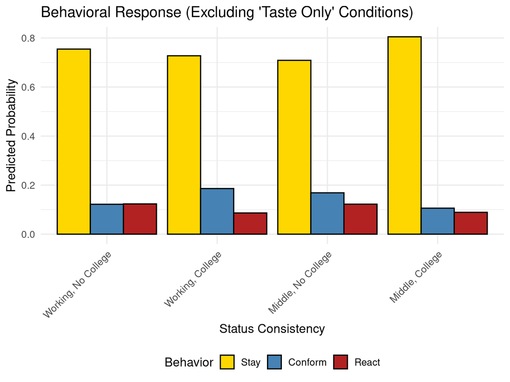

```r
# Filter out "Taste Only" conditions
df_multi_sens <- df_multi_wt %>%
  filter(!cond2_factor %in% c("Taste Only/Like", "Taste Only/Dislike")) %>%
  mutate(cond2_factor = droplevels(cond2_factor))

multi_mod_sens <- multinom(behavior ~ objsubjclass_factor,
                           data = df_multi_sens, trace = FALSE)

multi_preds_sens <- predictions(multi_mod_sens, type = "probs", by = c("objsubjclass_factor", "group"))

ggplot(multi_preds_sens, aes(x = objsubjclass_factor, y = estimate, fill = group)) +
  geom_bar(stat = "identity", position = "dodge", color = "black") +
  scale_fill_manual(values = c("Stay" = "gold", "Conform" = "steelblue", "React" = "firebrick")) +
  labs(title = "Behavioral Response (Excluding 'Taste Only' Conditions)",
       x = "Status Consistency", y = "Predicted Probability", fill = "Behavior") +
  theme_minimal(base_size = 14) +
  theme(legend.position = "bottom", axis.text.x = element_text(angle = 45, hjust = 1))
```

The probability distributions of conformity versus reactance remain highly consistent with the main findings, confirming that the presence of class-based status information uniquely structures the evaluation shifts of respondents.

# 4. Discussion and Conclusion

Taste is indeed a social product, shaped continuously by class consciousness, educational capital, and the omnipresent evaluation of our peers.